# Integrating terminal element variability into WBE

The assumption of invariance of terminal tips effectively leads to the assumption that the number of terminal elements is proportional to the metabolic capacity of the network, or $n_{N} \propto V_{N}^{L}$. Estimates of metabolic scaling fail because this is not the case, as we’ve shown previously. Returning to the original scaling argument, the result of applying a geometric series to the network model is

$$\begin{equation}
\label{eq:1}
V_{N}C_{0}N_{N}^{4/3} = V_{net}
\end{equation}$$

One approach to allowing variation in terminal tips is to replace $V_{N}$ with a series of random variables $\overline{r_{k}}^{2} \overline{l_{k}} \pi = \overline{V_{N}}$, where $\overline{V_{N}}$ now represents the average terminal tip volume for a vascular network. Substituting directly into the expression resulting from the geometric series we have

$$\overline{V_{N}}N_{N}^{4/3} = V_{net}$$
$$N_{N}^{4/3} = V_{net}/\overline{V_{N}}$$
$$N_{N} \propto (V_{net}/\overline{V_{N}})^{3/4}$$

where $\overline{V_{N}}$ is included in the scaling relationship because the average volume of terminal tips may very within and across vascular networks. We computed this correction to the empirical scaling by quantifying $\overline{V_{N}}$ as the geometric mean in volumes of distal terminal tips for a given (sub)tree. However, this approach fails. This is likely because variability in terminal tips propagates and scales throughout the network, proper accounting of which necessitates revising the geometric series.

Here, we attempt to modify the derivation using the geometric series, incorporating new scaling ratios intended to account for variability in terminal tip dimensions across a network.

First, we return to the definition of space filling in the context of length scaling:

$$\frac{N_{k}l_{k}^{3}}{N_{k+1}l_{k+1}^{3}} = 1$$

This statement formalizes the concept of a ‘service volume’ in WBE, and provides the definition for the length scaling ratio $\gamma = \frac{l_{k+1}}{l_{k}}$ in terms of the branching ratio $n = \frac{N_{k+1}}{N_{k}}$:

$$\frac{N_{k+1}l_{k+1}^{3}}{N_{k}l_{k}^{3}} = 1$$
$$n\gamma^{3} = 1$$
$$\gamma = n^{-1/3}$$

Our intuition is that modifying the definition of $\gamma$ will allow tip variability to enter into the theory, and particularly to propagate iteself through the geometric series. Now we introduce a length deviation factor for any branch at depth k as $\gamma^{*} = \frac{l_k}{\overline{l_{k}}}$ which is the ratio of the branch length to the mean length $\overline{l_{k}}$ at depth k. How is this related to terminal tip variability? If the expression for $\gamma^{*}$ is true, then

$$l_{k} = \overline{l_{N}}(\gamma^{*})^{N-k}$$

will also be true. This allows us to link tip variability (in the form of random variables $\overline{l_{N}}$ and more generally $\overline{l_{k}}$) to any level of the network using the scaling ratio $\gamma^{*}$. However we have no proof of this and it is questionable, since unlike $\gamma$, $\gamma^{*}$ must vary throughout the network. This makes it more difficult to link the terminal level of the hierarchy N with an arbitrary level k, which is the power of symmetry and the geometric series in WBE. Therefore, some other definition of $\gamma^{*}$ may be more appropriate.

However, if terminal element variability has an effect on scaling then some factor like $\gamma^{*}$ must exist. The intention is to introduce a new scaling ratio that might modify our predictions for metabolic scaling by integrating it into the geometric series. In order to do this, we need to express the new scaling ratio in terms of the branching ratio n. In the symmetric case (equivalent terminal tips) we would expect $\gamma^{*} = 1$, where for each branch level l, $l_{k} = \overline{l_{k}}$. Then, if $\gamma^{*} = n^{-x}$, then in the symmetric case $x = 0$ so that $\gamma^{*} = 1$ has no overall effect on the scaling of the network and ‘drops out’ of the theory. Thus, our first major prediction is that $x \neq 0$, and we propose to test this using the relationship

$$x = \frac{log \gamma^{*}}{log n}$$

Furthermore, if the definition for $\gamma^{*}$ holds true, we can show that the characteristic exponent $x$ shows up in the final expression for metabolic scaling of the number of terminal tips $n_{N}$ such that

$$n_{N} \propto V_{net}^{3/4 + x}$$

Likewise, an independent scale factor for terminal radii could be incorporated, but there is some evidence that variation in terminal elements is primarily driven by variation in lengths in LiDAR scans of trees. Furthermore, the concept of service volumes is inherently related to length scaling so we limit our investigation to the new factor $\gamma^{*}$ for the time being.

If our two predictions for the value $x$ are well-supported, it may be worthwhile to incorporate the new scale factor into expressions for $\theta$ including other branching traits. Currently, the assumptions involved in the definition for $\gamma^{*}$ are not clear, and the nature of the definition may need to change to more properly account for variation in terminal element geometry at each level of the network.

A major problem is that $\gamma^{*}$ is not a compensatory factor. Any variation in terminal tips will result in a reduction of the metabolic scaling exponent below 3/4. This would be consistent with our results from tip counting, but volume scaling regressions indicate that we should still expect a 3/4 scaling result. All that $\gamma^{*}$ can do is allow us to once again make predictions using the original, symmetric WBE theory based on integer counts of terminal elements. However, if using $\gamma^{*}$ allows us to recover the original theory, we have evidence that terminal tip variability may be heavily contributing to observed variation in metabolic scaling exponents. Below, we attempt to quanity $\gamma^{*}$ and evaluate the predictions it entails.

First, the variation in $\gamma^{*}$ is consistent with a long tail in the geometry of branches, such that a few large branches pollute data on many small terminal elements

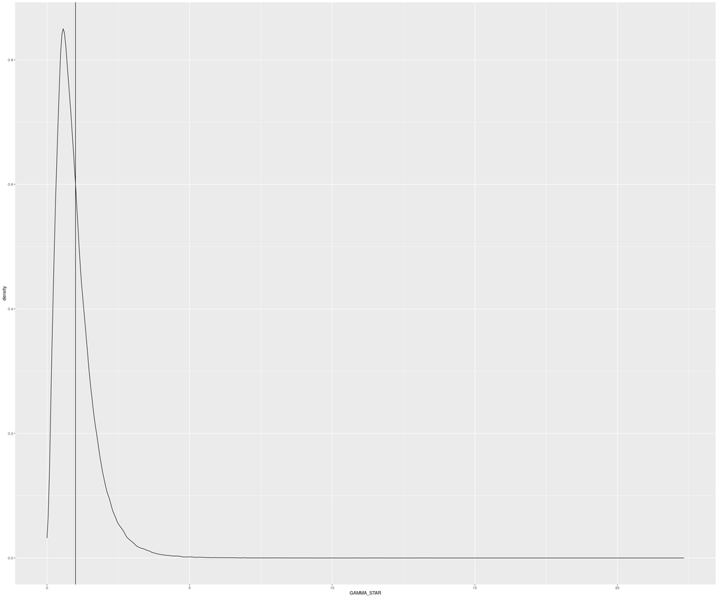

To evaluate this theory, our goal is to improve on the relationship between tip scaling exponents and volume scaling exponents shown here

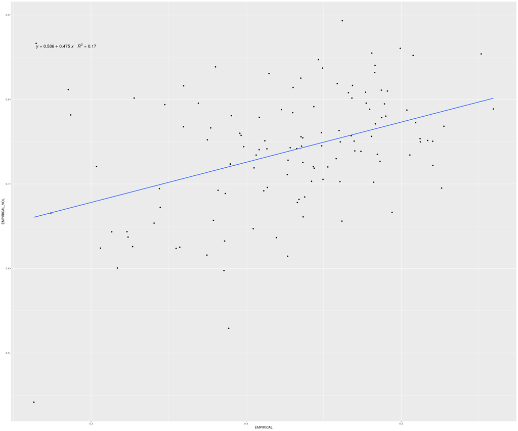

We would predict a slope of 1 between these two axes, but the slope is shallow and the trend line exhibits significant scatter.

We calculated a mean value of $x$ for each tree by computing
$$\frac{log \gamma^{*}}{log n}$$
at each node, and taking the mean value of this exponent across all nodes. Then, we applied the $x$ value as a correction to the ‘true’ metabolic scaling exponent calculated from volume scaling regressions. Below, we regress this corrected scaling exponent against tip scaling exponents (based on the integer number of distal tips across subtrees)

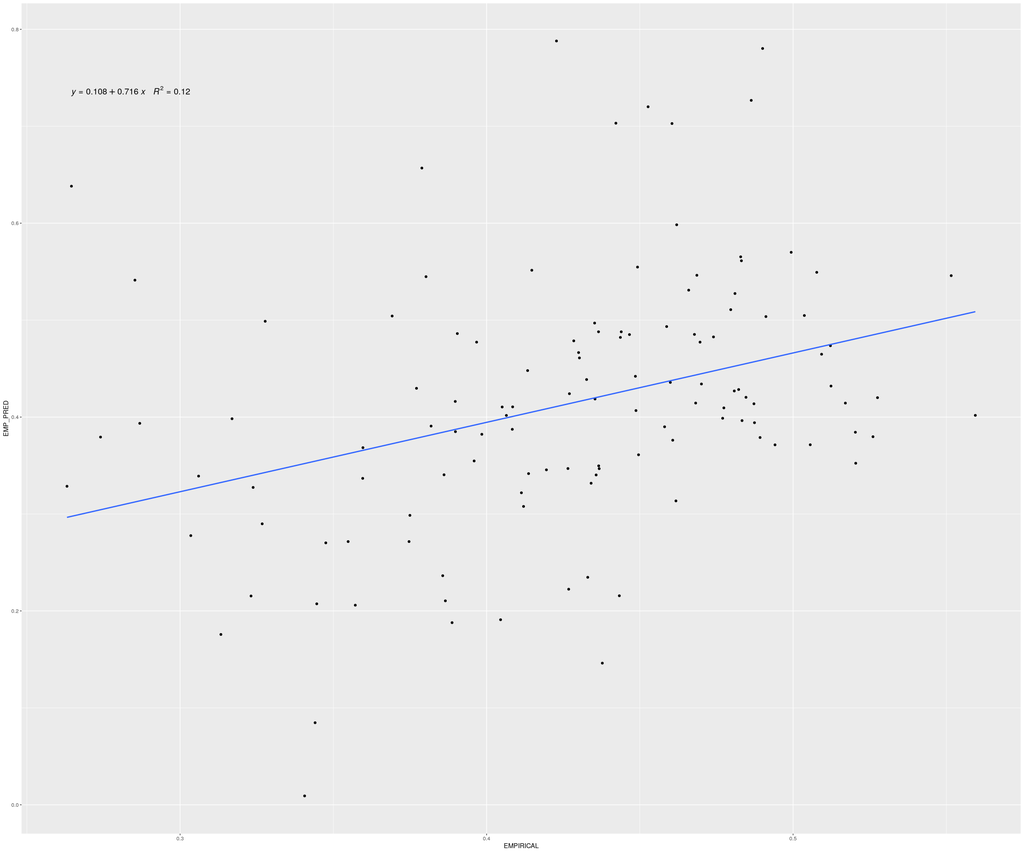

The addition of the scaling ratio $\gamma^{*}$ is moderately successful, to the extent that it steepens the slope between tip counting scaling exponents and corrected volume scaling exponents (from a slope of ~0.47 to a slope of about ~0.71). However, the method seems to add more variability to the dataset and increases the scattter, reducing the adjusted $R^{2}$ fit quality.